# Quality Control and Differential Gene Expression Analysis, Candida glabrata

Weronika Danecka and Edward Wallace

2024-05-23

# Introduction

Candida glabrata strains:

1. CBS138
2. BG2

Treated with voriconazole (VCZ / VORI), fluconazole (FCZ / FLUC) or DMSO (solvent control).

Sequencing FASTQ files were aligned to appropriate genomes using HISAT2 and quantified using featureCounts.

MultiQC results, including quality control of raw reads (FastQC) and alignment are here:

- CBS138: ../data/multiQC/Candida_glabrata_CBS138/multiqc_report.html)
- BG2: ../data/multiQC/Candida_glabrata_BG2/multiqc_report.html)

featureCount results, aggregated by strain, are below:

```r
counts_all_CBS138 = read.table("../data/featureCounts/Candida_glabrata_CBS138/CBS138_all_conditions_featureCounts.tab", header=TRUE)
counts_all_BG2 = read.table("../data/featureCounts/Candida_glabrata_BG2/BG2_all_conditions_featureCounts.tab", header=TRUE)

counts_rpm_CBS138 = read.table("../data/featureCounts/Candida_glabrata_CBS138/CBS138_all_conditions_rpm.tab", header=TRUE, row.names = 1)
counts_rpm_BG2 = read.table("../data/featureCounts/Candida_glabrata_BG2/BG2_all_conditions_rpm.tab", header=TRUE, row.names = 1)

head(counts_all_CBS138) # CBS138, raw
```

```
##         Geneid CBS138_RPMI_DMSO_A CBS138_RPMI_VORI_A CBS138_RPMI_FLUC_A
## 0 CAGL0A00165g                329               1277                953
## 1 CAGL0A00187g                541               1561               1755
## 2 CAGL0A00209g               2460               6237               7252
## 3 CAGL0A00231g                243                172                375
## 4 CAGL0A00253g                791               2009               2340
## 5 CAGL0A00275g               1295               2665               2876
##   CBS138_RPMI_DMSO_B CBS138_RPMI_VORI_B CBS138_RPMI_FLUC_B CBS138_RPMI_DMSO_C
## 0                653                873               1124                422
## 1               1240               1434               1990                950
## 2               5037               6009               7581               3992
## 3                292                305                235                426
## 4               1336               2031               2071               1217
## 5               2133               2716               2933               1643
##   CBS138_RPMI_VORI_C CBS138_RPMI_FLUC_C
## 0                436               3425
## 1               1120               7031
## 2               1345              18963
## 3                118               1572
## 4                395               8426
## 5                488               8892
```

```r
head(counts_all_BG2) # BG2, raw
```

```
##         Geneid BG2_RPMI_DMSO_A BG2_RPMI_VORI_A BG2_RPMI_FLUC_A BG2_RPMI_DMSO_B
## 0 GWK60_A00011               1               1               1               1
## 1 GWK60_A00033             100             169              93             116
## 2 GWK60_A00055            1490            2411            1982            1417
## 3 GWK60_A00077            4781            8038            6834            5852
## 4 GWK60_A00099           14463           20284           15228           15459
## 5 GWK60_A00121            2371            1412             816            2188
##   BG2_RPMI_VORI_B BG2_RPMI_FLUC_B BG2_RPMI_DMSO_C BG2_RPMI_VORI_C
## 0               1               3               1               1
## 1             194              17             123              19
## 2            2422             304            1838             223
## 3            7534            1569            5704            1015
## 4           18965            2859           17357            1804
## 5             979             136            3000              63
##   BG2_RPMI_FLUC_C
## 0               1
## 1              26
## 2             394
## 3            1236
## 4            2528
## 5             146
```

Results normalised to RPM are below:

```r
head(counts_rpm_CBS138) # CBS138, normalised to RPM
```

```
##              CBS138_RPMI_DMSO_A CBS138_RPMI_VORI_A CBS138_RPMI_FLUC_A
## CAGL0A00165g           30.85212           65.75689           46.30258
## CAGL0A00187g           50.73251           80.38097           85.26866
## CAGL0A00209g          230.68756          321.16343          352.34663
## CAGL0A00231g           22.78743            8.85684           18.21980
## CAGL0A00253g           74.17637          103.44995          113.69155
## CAGL0A00275g          121.43918          137.22953          139.73371
##              CBS138_RPMI_DMSO_B CBS138_RPMI_VORI_B CBS138_RPMI_FLUC_B
## CAGL0A00165g           38.03028           47.18167           51.79789
## CAGL0A00187g           72.21676           77.50116           91.70624
## CAGL0A00209g          293.35146          324.75904          349.35928
## CAGL0A00231g           17.00588           16.48386           10.82963
## CAGL0A00253g           77.80773          109.76629           95.43900
## CAGL0A00275g          124.22447          146.78741          135.16301
##              CBS138_RPMI_DMSO_C CBS138_RPMI_VORI_C CBS138_RPMI_FLUC_C
## CAGL0A00165g           32.91856           49.17631           46.07813
## CAGL0A00187g           74.10577          126.32448           94.59134
## CAGL0A00209g          311.40026          151.70216          255.11813
## CAGL0A00231g           33.23059           13.30919           21.14885
## CAGL0A00253g           94.93340           44.55194          113.35893
## CAGL0A00275g          128.16398           55.04138          119.62824
```

```r
head(counts_rpm_BG2) # BG2, normalised to RPM
```

```
##              BG2_RPMI_DMSO_A BG2_RPMI_VORI_A BG2_RPMI_FLUC_A BG2_RPMI_DMSO_B
## GWK60_A00011      0.01411581      0.01238536      0.01580123      0.01571183
## GWK60_A00033      1.41158064      2.09312569      1.46951436      1.82257193
## GWK60_A00055     21.03255147     29.86110080     31.31803713     22.26365885
## GWK60_A00077     67.48767020     99.55351647    107.98560331     91.94561156
## GWK60_A00099    204.15690735    251.22462406    240.62112485    242.88913348
## GWK60_A00121     33.46857687     17.48812705     12.89380338     34.37747746
##              BG2_RPMI_VORI_B BG2_RPMI_FLUC_B BG2_RPMI_DMSO_C BG2_RPMI_VORI_C
## GWK60_A00011       0.0130404       0.2616564      0.01394962       0.1205643
## GWK60_A00033       2.5298376       1.4827197      1.71580380       2.2907212
## GWK60_A00055      31.5838485      26.5145175     25.63940963      26.8858332
## GWK60_A00077      98.2463727     136.8463092     79.56865753     122.3727387
## GWK60_A00099     247.3111836     249.3585711    242.12363055     217.4979513
## GWK60_A00121      12.7665515      11.8617578     41.84887317       7.5955493
##              BG2_RPMI_FLUC_C
## GWK60_A00011      0.09884977
## GWK60_A00033      2.57009413
## GWK60_A00055     38.94681101
## GWK60_A00077    122.17832084
## GWK60_A00099    249.89222903
## GWK60_A00121     14.43206702
```

## Match genes across strains using Reciprocal Blast Best Hits

The genes between the two strains are matched using Reciprocal Blast Best Hits, which might not be entirely accurate given copy number variations etc. between the two species. I have used orthofinder https://doi.org/10.1186/s13059-019-1832-y to find orthologs, but I haven’t found a way to incorporate this into the analysis yet.

```r
# Load reciprocal BLAST best hits
rbbh = read.csv("../data/rbbh/cbs138_bg2_rbbh2.csv")

# merge on CBS138 gene names,
counts_all_CBS138_rbbh = merge(counts_all_CBS138, rbbh,
                               by.x="Geneid", by.y="gene_id_cbs138")

# combine counts from common genes.
counts_all_joined = merge(counts_all_CBS138_rbbh,
                          dplyr::rename(counts_all_BG2, gene_id_bg2 = "Geneid"),
                          by = "gene_id_bg2")
head(counts_all_joined)
```

```
##    gene_id_bg2       Geneid CBS138_RPMI_DMSO_A CBS138_RPMI_VORI_A
## 1 GWK60_A00011 CAGL0H10626g                119                153
## 2 GWK60_A00055 CAGL0A00165g                329               1277
## 3 GWK60_A00077 CAGL0A00187g                541               1561
## 4 GWK60_A00099 CAGL0A00209g               2460               6237
## 5 GWK60_A00121 CAGL0A00231g                243                172
## 6 GWK60_A00143 CAGL0A00253g                791               2009
##   CBS138_RPMI_FLUC_A CBS138_RPMI_DMSO_B CBS138_RPMI_VORI_B CBS138_RPMI_FLUC_B
## 1                371                218                354                317
## 2                953                653                873               1124
## 3               1755               1240               1434               1990
## 4               7252               5037               6009               7581
## 5                375                292                305                235
## 6               2340               1336               2031               2071
##   CBS138_RPMI_DMSO_C CBS138_RPMI_VORI_C CBS138_RPMI_FLUC_C BG2_RPMI_DMSO_A
```

[output cut: 20 more lines]

# Analysis

## Quality control - sample correlation

For quality control, we check correlation between the samples (only within strain).

(This is a figure in progress)

When we cluster the results, again untreated samples cluster together and treated samples cluster together. Treated samples cluster in a way that doesn’t indicate any obvious sample mix-up.

CBS138_RPMI_VORI_C is an outlier.

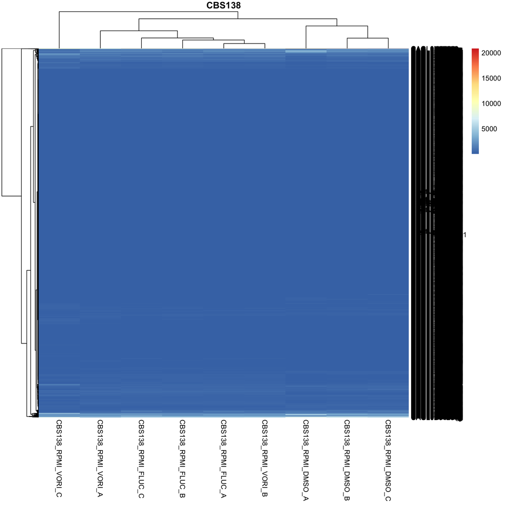

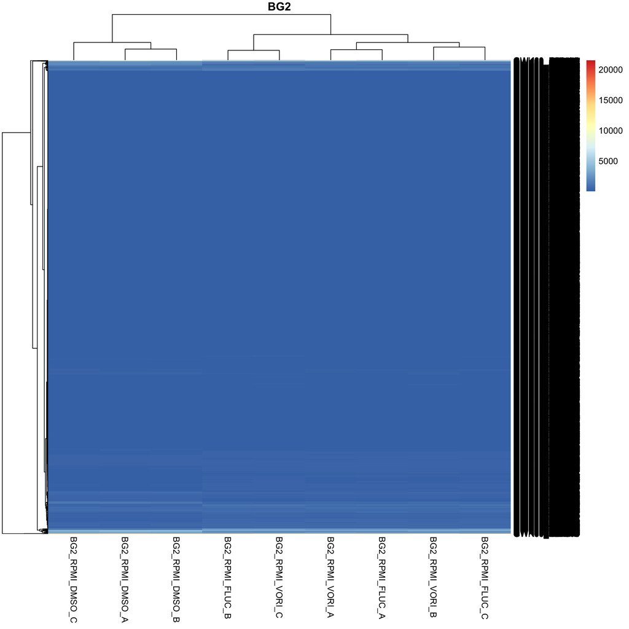

## Quality Control - Principal Component Analysis

```r
sample_sheet_all = here::here("data",
                         "sample_sheets",
                         "DGE_samplesheet_canGla2.txt") %>%
  read_table()
# samplesheet = py$experiment_data_both
rownames(sample_sheet_all) = sample_sheet_all$Code
print(sample_sheet_all)
```

```
## # A tibble: 18 × 9
##    SampleID Code               Medium Temp  Time  Rep   Species Strain Condition
##  *    <dbl> <chr>              <chr>  <chr> <chr> <chr> <chr>   <chr>  <chr>
##  1       86 CBS138_RPMI_DMSO_A RPMI_… 37C   4h    A     Candid… CBS138 CBS138_R…
##  2       87 CBS138_RPMI_VORI_A RPMI_… 37C   4h    A     Candid… CBS138 CBS138_R…
##  3       88 CBS138_RPMI_FLUC_A RPMI_… 37C   4h    A     Candid… CBS138 CBS138_R…
##  4       89 BG2_RPMI_DMSO_A    RPMI_… 37C   4h    A     Candid… BG2    BG2_RPMI…
##  5       90 BG2_RPMI_VORI_A    RPMI_… 37C   4h    A     Candid… BG2    BG2_RPMI…
##  6       91 BG2_RPMI_FLUC_A    RPMI_… 37C   4h    A     Candid… BG2    BG2_RPMI…
##  7       92 CBS138_RPMI_DMSO_B RPMI_… 37C   4h    B     Candid… CBS138 CBS138_R…
##  8       93 CBS138_RPMI_VORI_B RPMI_… 37C   4h    B     Candid… CBS138 CBS138_R…
##  9       94 CBS138_RPMI_FLUC_B RPMI_… 37C   4h    B     Candid… CBS138 CBS138_R…
## 10       98 BG2_RPMI_DMSO_B    RPMI_… 37C   4h    B     Candid… BG2    BG2_RPMI…
## 11       99 BG2_RPMI_VORI_B    RPMI_… 37C   4h    B     Candid… BG2    BG2_RPMI…
## 12      100 BG2_RPMI_FLUC_B    RPMI_… 37C   4h    B     Candid… BG2    BG2_RPMI…
## 13       95 CBS138_RPMI_DMSO_C RPMI_… 37C   4h    C     Candid… CBS138 CBS138_R…
## 14       96 CBS138_RPMI_VORI_C RPMI_… 37C   4h    C     Candid… CBS138 CBS138_R…
## 15       97 CBS138_RPMI_FLUC_C RPMI_… 37C   4h    C     Candid… CBS138 CBS138_R…
## 16      101 BG2_RPMI_DMSO_C    RPMI_… 37C   4h    C     Candid… BG2    BG2_RPMI…
## 17      102 BG2_RPMI_VORI_C    RPMI_… 37C   4h    C     Candid… BG2    BG2_RPMI…
## 18      103 BG2_RPMI_FLUC_C    RPMI_… 37C   4h    C     Candid… BG2    BG2_RPMI…
```

```r
dds_all <- DESeqDataSetFromMatrix(countData =
                                    counts_all_joined %>%
                             dplyr::select(sample_sheet_all$Code) %>%
                             magrittr::set_rownames(counts_all_joined$Gene),
                                  colData = sample_sheet_all,
                                  design = ~ Code)
rlog_all <- rlog(dds_all)
head(assay(rlog_all))
```

```
##              CBS138_RPMI_DMSO_A CBS138_RPMI_VORI_A CBS138_RPMI_FLUC_A
## CAGL0H10626g           7.532662           7.046592           7.803483
## CAGL0A00165g           9.819161          10.247470           9.981287
## CAGL0A00187g          10.850525          11.007853          11.079555
## CAGL0A00209g          12.708113          12.783775          12.891339
## CAGL0A00231g           9.134426           8.283834           8.798710
## CAGL0A00253g          11.102017          11.177522          11.284519
##              BG2_RPMI_DMSO_A BG2_RPMI_VORI_A BG2_RPMI_FLUC_A CBS138_RPMI_DMSO_B
## CAGL0H10626g        5.262604        5.237443        5.253129           7.578427
## CAGL0A00165g        9.575449        9.699059        9.706994           9.911436
## CAGL0A00187g       11.105937       11.269220       11.305368          11.037381
## CAGL0A00209g       12.660509       12.678386       12.613487          12.830194
## CAGL0A00231g        9.522984        8.829991        8.578657           8.830633
## CAGL0A00253g       11.176013       11.266810       11.107186          11.065763
##              CBS138_RPMI_VORI_B CBS138_RPMI_FLUC_B BG2_RPMI_DMSO_B
## CAGL0H10626g           7.866795           7.604660        5.264334
## CAGL0A00165g          10.004430          10.069135        9.552677
## CAGL0A00187g          11.013891          11.131689       11.283900
## CAGL0A00209g          12.830300          12.878901       12.730468
## CAGL0A00231g           8.731257           8.427881        9.468714
## CAGL0A00253g          11.263050          11.135540       11.118469
##              BG2_RPMI_VORI_B BG2_RPMI_FLUC_B CBS138_RPMI_DMSO_C
## CAGL0H10626g        5.239410        5.617187           7.879963
## CAGL0A00165g        9.723904        9.631222           9.758397
## CAGL0A00187g       11.239058       11.554708          11.019457
## CAGL0A00209g       12.646469       12.694132          12.838603
## CAGL0A00231g        8.581103        8.570093           9.332638
## CAGL0A00253g       11.140956       11.142942          11.186040
##              CBS138_RPMI_VORI_C CBS138_RPMI_FLUC_C BG2_RPMI_DMSO_C
## CAGL0H10626g           8.178808           8.388479        5.254219
## CAGL0A00165g          10.166875          10.021087        9.659647
## CAGL0A00187g          11.533233          11.203325       11.169054
## CAGL0A00209g          12.350243          12.666644       12.730393
## CAGL0A00231g           8.690081           8.954762        9.647514
## CAGL0A00253g          10.688575          11.326460       11.138934
##              BG2_RPMI_VORI_C BG2_RPMI_FLUC_C
## CAGL0H10626g        5.606251        5.549291
## CAGL0A00165g        9.623289        9.889308
## CAGL0A00187g       11.440342       11.419485
## CAGL0A00209g       12.563927       12.655815
## CAGL0A00231g        8.276823        8.672952
## CAGL0A00253g       10.997610       11.221235
```

```r
rlog_all_df = as.data.frame(assay(rlog_all))
```

```r
# calculate principal components of rlog, after extracting from the dataset
pca_rlog <- rlog_all %>%
  assay() %>%
  t() %>%
  prcomp()

# convert principal components to data frame
pcdf_rlog <- bind_cols(
  as_tibble(colData(rlog_all)),
  as_tibble(pca_rlog$x)
)

pcdf_rlog
```

```
## # A tibble: 18 × 28
##    SampleID Code    Medium Temp  Time  Rep   Species Strain Condition sizeFactor
##       <dbl> <fct>   <chr>  <chr> <chr> <chr> <chr>   <chr>  <chr>          <dbl>
##  1       86 CBS138… RPMI_… 37C   4h    A     Candid… CBS138 CBS138_R…      0.368
##  2       87 CBS138… RPMI_… 37C   4h    A     Candid… CBS138 CBS138_R…      0.851
##  3       88 CBS138… RPMI_… 37C   4h    A     Candid… CBS138 CBS138_R…      0.870
##  4       89 BG2_RP… RPMI_… 37C   4h    A     Candid… BG2    BG2_RPMI…      2.29
##  5       90 BG2_RP… RPMI_… 37C   4h    A     Candid… BG2    BG2_RPMI…      3.14
##  6       91 BG2_RP… RPMI_… 37C   4h    A     Candid… BG2    BG2_RPMI…      2.56
##  7       92 CBS138… RPMI_… 37C   4h    B     Candid… CBS138 CBS138_R…      0.650
##  8       93 CBS138… RPMI_… 37C   4h    B     Candid… CBS138 CBS138_R…      0.775
##  9       94 CBS138… RPMI_… 37C   4h    B     Candid… CBS138 CBS138_R…      0.923
## 10       98 BG2_RP… RPMI_… 37C   4h    B     Candid… BG2    BG2_RPMI…      2.25
## 11       99 BG2_RP… RPMI_… 37C   4h    B     Candid… BG2    BG2_RPMI…      3.06
## 12      100 BG2_RP… RPMI_… 37C   4h    B     Candid… BG2    BG2_RPMI…      0.435
## 13       95 CBS138… RPMI_… 37C   4h    C     Candid… CBS138 CBS138_R…      0.510
## 14       96 CBS138… RPMI_… 37C   4h    C     Candid… CBS138 CBS138_R…      0.318
## 15       97 CBS138… RPMI_… 37C   4h    C     Candid… CBS138 CBS138_R…      2.98
## 16      101 BG2_RP… RPMI_… 37C   4h    C     Candid… BG2    BG2_RPMI…      2.52
## 17      102 BG2_RP… RPMI_… 37C   4h    C     Candid… BG2    BG2_RPMI…      0.323
## 18      103 BG2_RP… RPMI_… 37C   4h    C     Candid… BG2    BG2_RPMI…      0.403
## # ℹ 18 more variables: PC1 <dbl>, PC2 <dbl>, PC3 <dbl>, PC4 <dbl>, PC5 <dbl>,
## #   PC6 <dbl>, PC7 <dbl>, PC8 <dbl>, PC9 <dbl>, PC10 <dbl>, PC11 <dbl>,
## #   PC12 <dbl>, PC13 <dbl>, PC14 <dbl>, PC15 <dbl>, PC16 <dbl>, PC17 <dbl>,
## #   PC18 <dbl>
```

```r
propvar_rlog_df <- tibble(
  PC = seq.int(1L, ncol(pca_rlog$x) ),
  tot_var = pca_rlog$sdev^2,
  prop_var = tot_var/sum(tot_var)
)

propvar_rlog_df
```

```
## # A tibble: 18 × 3
##       PC  tot_var prop_var
##    <int>    <dbl>    <dbl>
##  1     1 1.68e+ 2 3.58e- 1
##  2     2 1.55e+ 2 3.31e- 1
##  3     3 6.87e+ 1 1.46e- 1
##  4     4 1.82e+ 1 3.88e- 2
##  5     5 1.60e+ 1 3.40e- 2
##  6     6 1.26e+ 1 2.68e- 2
##  7     7 5.75e+ 0 1.22e- 2
##  8     8 4.79e+ 0 1.02e- 2
##  9     9 3.80e+ 0 8.08e- 3
## 10    10 3.32e+ 0 7.07e- 3
## 11    11 3.07e+ 0 6.54e- 3
## 12    12 2.48e+ 0 5.28e- 3
## 13    13 2.09e+ 0 4.45e- 3
## 14    14 1.78e+ 0 3.79e- 3
## 15    15 1.29e+ 0 2.75e- 3
## 16    16 1.14e+ 0 2.44e- 3
## 17    17 1.04e+ 0 2.21e- 3
## 18    18 1.07e-26 2.29e-29
```

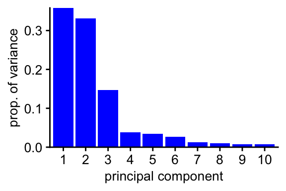

```r
plot_percentvar_rlog <-
  ggplot(data = propvar_rlog_df,
         aes(x = PC, y = prop_var)) +
  geom_col(fill = "blue") +
  scale_x_continuous("principal component",
                     limits = c(0.4,10.6),
                     breaks = 1L:10L,
                     expand = c(0,0)) +
  scale_y_continuous("prop. of variance", expand = c(0,0))
plot_percentvar_rlog
```

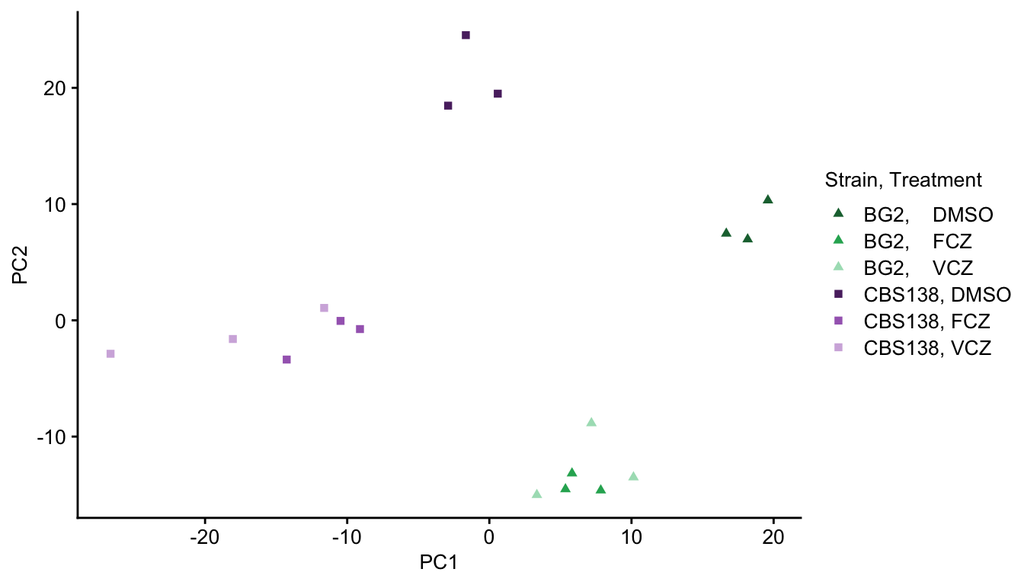

```r
scales_PCA <-
  list(
    scale_colour_manual("Strain, Treatment",
      values = c("CBS138_RPMI_DMSO" = "#5B2C6F",
                 "CBS138_RPMI_FLUC" = "#A569BD",
                 "CBS138_RPMI_VORI" = "#D2B4DE",
                 "BG2_RPMI_DMSO" = "#196F3D",
                 "BG2_RPMI_FLUC" = "#27AE60",
                 "BG2_RPMI_VORI" = "#A9DFBF"),
      labels = c("CBS138_RPMI_DMSO" = "CBS138, DMSO",
                 "CBS138_RPMI_FLUC" = "CBS138, FCZ",
                 "CBS138_RPMI_VORI" = "CBS138, VCZ",
                 "BG2_RPMI_DMSO"    = "BG2,    DMSO",
                 "BG2_RPMI_FLUC"    = "BG2,    FCZ",
                 "BG2_RPMI_VORI"    = "BG2,    VCZ")),
    scale_shape_manual("Strain, Treatment",
      values = c("CBS138_RPMI_DMSO" = 15,
                 "CBS138_RPMI_FLUC" = 15,
                 "CBS138_RPMI_VORI" = 15,
                 "BG2_RPMI_DMSO" = 17,
                 "BG2_RPMI_FLUC" = 17,
                 "BG2_RPMI_VORI" = 17),
      labels = c("CBS138_RPMI_DMSO" = "CBS138, DMSO",
                 "CBS138_RPMI_FLUC" = "CBS138, FCZ",
                 "CBS138_RPMI_VORI" = "CBS138, VCZ",
                 "BG2_RPMI_DMSO"    = "BG2,    DMSO",
                 "BG2_RPMI_FLUC"    = "BG2,    FCZ",
                 "BG2_RPMI_VORI"    = "BG2,    VCZ"))
  )


pc12 = ggplot(data = pcdf_rlog,
       aes(colour = Condition, shape = Condition)
       ) +
  geom_point(aes(x = PC1, y = PC2)) +
  theme(legend.box = "horizontal") +
  scales_PCA
legend = get_legend(pc12)
pc12
```

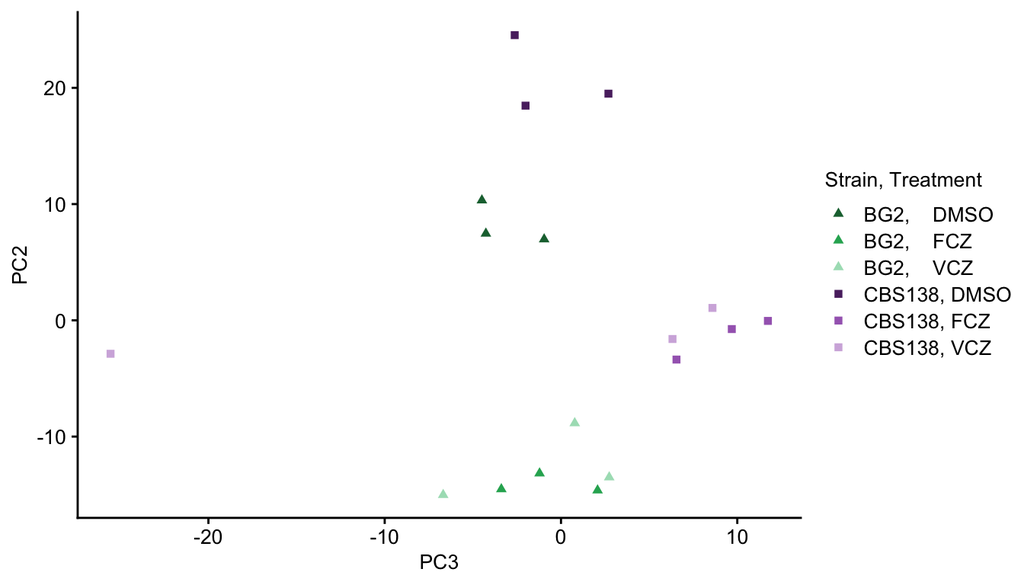

```r
pc32 = ggplot(data = pcdf_rlog,
       aes(colour = Condition, shape = Condition)
       ) +
  geom_point(aes(x = PC3, y = PC2)) +
  scales_PCA
pc32
```

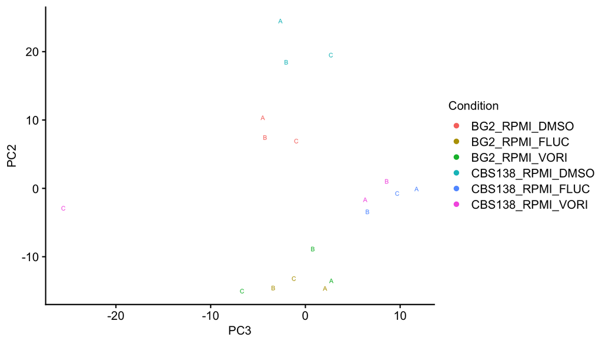

```r
ggplot(data = pcdf_rlog,
       aes(colour = Condition, shape = Rep)
       ) +
  geom_point(aes(x = PC3, y = PC2)) +
  scale_shape_identity()
```

```r
# TODO: change styling to include shapes: circles squares triangles, maybe add Vs and Fs
```

Conclusions:

In PC1 vs PC2 there are 4 clear clusters: corresponding to treated and untreated strains BG2 and CBS138. In PC3 they look more similar.

The outlier: CBS138_RPMI_VORI_C (light purple) clusters with other bio reps in PC1-PC2, but not in PC3. After discussion, we decided that something was not quite right in that replicate.

## Differential Gene Expression analysis using DESeq2 in each strain separately

Differential Gene Expression analysis was performed using DESeq2. Genes with adjusted p-value < 0.05 and at least 2x change are considered differentially expressed here. The upregulated and downregulated genes are saved in ../data/deseq2

### DGE, CBS138, FCZ vs DMSO

### DGE, CBS138, VCZ vs DMSO

Conclude: the single outlying sample `CBS138_RPMI_VORI_C` has minimal effect on the substantial results. Although it changes the genelists over the cutoff, it doesn’t change much most of the fold changes and p-values.

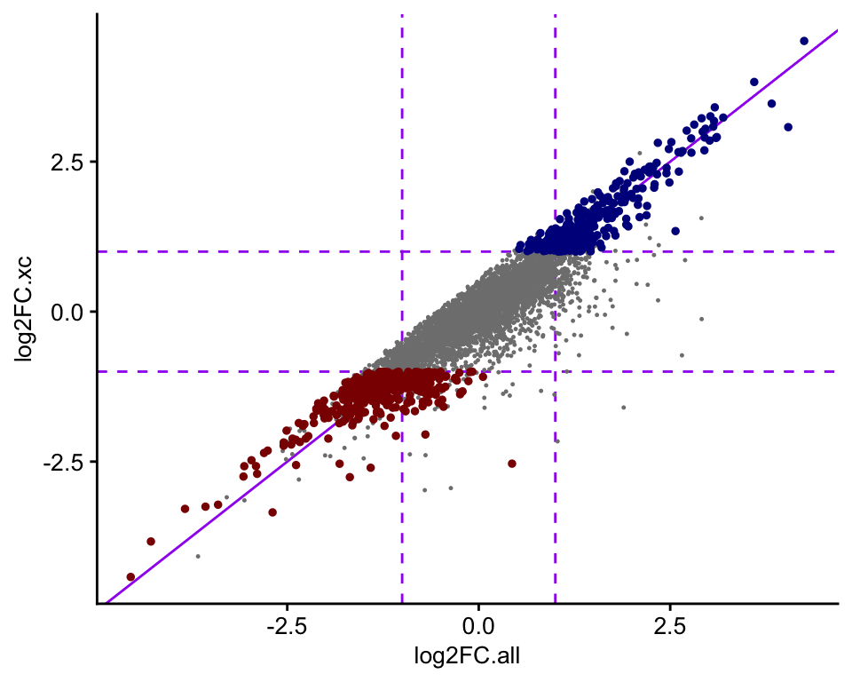

### DGE, CBS138, VCZ vs FCZ

### Double-check: DGE, CBS138, VCZ vs FCZ excluding the outlying sample CBS138_RPMI_VORI_C

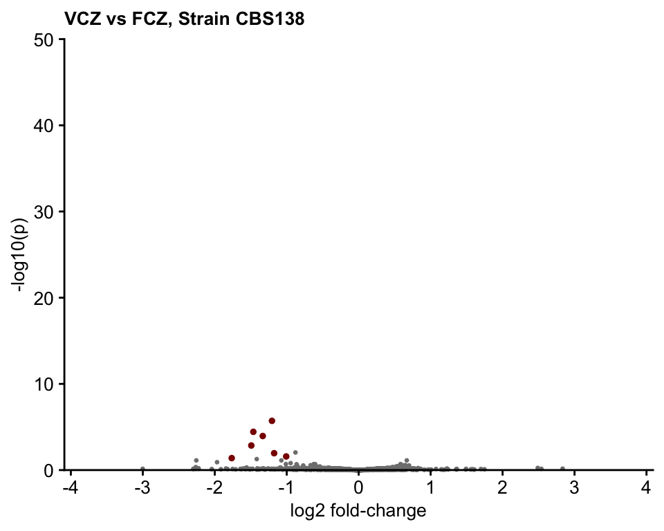

Again this does not substantially change outcome: 7 DE genes when the sample is excluded, instead of zero.

### DGE, BG2, FCZ vs DMSO

### DGE, BG2, VCZ vs DMSO

### DGE, BG2, VCZ vs FCZ

### Volcano plots of pairwise comparisons

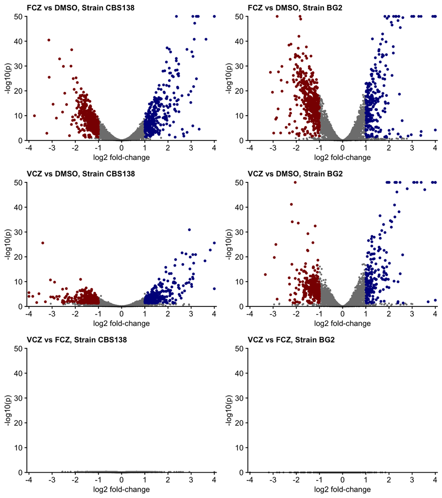

How many genes were differentially expressed in each condition? [TODO: make it a figure]

CBS138:

```
## [1] "Upregulated CBS138 FCZ vs DMSO: 321"
```

```
## [1] "Downregulated CBS138 FCZ vs DMSO: 409"
```

```
## [1] "Upregulated in CBS138 VCZ vs DMSO: 338"
```

```
## [1] "Downregulated in CBS138 VCZ vs DMSO: 353"
```

```
## [1] "Upregulated in CBS138 VCZ vs FCZ: 0"
```

```
## [1] "Downregulated in CBS138 VCZ vs FCZ: 0"
```

BG2:

```
## [1] "Upregulated in BG2 FCZ vs DMSO: 271"
```

```
## [1] "Downregulated in BG2 FCZ vs DMSO: 450"
```

```
## [1] "Upregulated in BG2 VCZ vs DMSO: 234"
```

```
## [1] "Downregulated in BG2 VCZ vs DMSO: 328"
```

```
## [1] "Upregulated in BG2 VCZ vs FCZ: 0"
```

```
## [1] "Downregulated in BG2 VCZ vs FCZ: 0"
```

### Identification of corresponding genes in S. cerevisiae and between the two C.glabrata strains

Using curated orthologs between C.glabrata CBS138 and S.cerevisiae (downloaded from candidagenome.org), I identified standard and systematic *S. cerevisiae* names for *C.glabrata* genes up- and down-regulated in FCZ vs DMSO. There is no need to do repeat it in VCZ, because there are no significant DEG between these two conditions.

Orthologs are also identified between C.glabrata strains using Reciprocal Blast Best Hits.

Here I look at overlap between genes upregulated/downregulated in FCZ treatment between CBS138 and BG2. This includes:

- reporting the number of genes that are DE in one strain and have a homolog in the other - this shows how many genes unique for the strain are DE
- reporting the number of genes that are DE in both strain - this shows whether the response is similar between CBS138 and BG2.

```
## [1] "Number of FCZ upregulated genes in CBS138: 321 that have a homolog in BG2: 314"
```

```
## [1] "Number of FCZ downregulated genes in CBS138: 409 that have a homolog in BG2: 405"
```

```
## [1] "Number of FCZ upregulated genes in BG2: 271 that have a homolog in CBS138: 258"
```

```
## [1] "Number of FCZ downregulated genes in BG2: 450 that have a homolog in CBS138: 443"
```

```
## [1] "Number of FCZ upregulated genes overlapping between CBS138 and BG2: 169"
```

```
## [1] "Number of FCZ downregulated genes overlapping between CBS138 and BG2: 269"
```

**Conclusions:**

- most upregulated genes have homologs in both strains
- only a little more than 50% of genes differentially expressed in one strain are also differentially expressed in the other

### Gene Ontology analysis of up- and down-regulated genes in CBS138 and BG2

Based on this, I used GO term enrichment (candidagenome.org) of up- and downregulated genes in CBS138, BG2 and common to both strains.

The results are in ../data/go/ folder.

#### Upregulated genes

Both strains up (selected):

- secondary alcohol biosynthetic process
- sterol and lipid biosynthetic process
- sulfur compound metabolic process
- secondary alcohol metabolic process
- small molecule metabolic process
- alcohol biosynthetic process
- small molecule biosynthetic process
- organic hydroxy compound biosynthetic process
- homoserine metabolic process
- non-proteinogenic amino acid metabolic process
- sulfur amino acid biosynthetic process
- aspartate family amino acid metabolic process
- amino acid import across plasma membrane
- L-methionine biosynthetic process

Only CBS138 up:

- carbohydrate metabolic process
- oligosaccharide metabolic process
- monosaccharide metabolic process
- trehalose metabolic process

BG2 only up (selected):

- lysine biosynthetic process via aminoadipic acid
- proteinogenic amino acid metabolic process
- L-amino acid metabolic process
- aspartate family amino acid biosynthetic process

**Conclusions:**

- both strains have upregulation of ergosterol and lipid biosynthesis genes and small molecule metabolism genes (which also includes ERG genes)
- BG2 DEG are more enriched in amino acid metabolism genes
- CBS138 are more enriched in carbohydrate metabolism genes - I think these are generally upregulated in stress?

#### Downregulated genes

Both strains down (selected):

- ribosome biogenes
- nucleic acid catabolism

CBS138 only:

- arginine biosynthetic process
- arginine metabolic process
- glutamine family amino acid biosynthetic process
- ornithine metabolic process
- arginine biosynthetic process via ornithine
- glutamine family amino acid metabolic process
- ribosome biogenesis

BG2 only:

- translation
- ribosome biogenesis

**Conclusions:**

- in both strains mostly ribosome biogenesis genes are downregulated

### Comparison with transcription factor targets

Using data from two publications, both in CBS138:

- UPC2A https://doi.org/10.1371/journal.pgen.1009582
- PDR1 https://doi.org/10.1128/aac.03921-14

I looked at differential expression of two transcription factor targets involved in antifungal resistance. This part of the analysis in CBS138 only.

This is not enrichment analysis, just search for overlapping genes.

For comparison, I’m also showing targets of *S. cerevisiae* homologs of these two genes (targets downloaded from SGD).

```
## [1] "Number of PDR1 targets in C.glabrata: 25, number of upregulated genes: 261, number of downregulated genes: 344"
```

```
## [1] "Intersection UP:"
```

```
## [1] "ATF2" "YOR1" "BAG7" "RTA1" "LAF1"
```

```
## [1] "Intersection DOWN:"
```

```
## [1] "PDR16" "RSB1"
```

```
## [1] "Number of PDR1 targets in S. cerevisiae: 44, , number of upregulated genes: 261, number of downregulated genes: 344"
```

```
## [1] "Intersection UP:"
```

```
## [1] "GSC2" "VPS4"
```

```
## [1] "Intersection DOWN:"
```

```
## [1] "RPC53" "RPO26"
```

```
## [1] "Number of UPC2A targets in C. glabrata: 237, , number of upregulated genes: 261, number of downregulated genes: 344"
```

```
## [1] "Intersection UP:"
```

```
## [1] "ERG1"    "YOR1"    "YOR1"    "YOR1"    "YOR1"    "YNR014W" "YER158C"
## [8] "HEM13"   "ADP1"
```

```
## [1] "Intersection DOWN:"
```

```
##  [1] "PMA1"      "PMA1"      "YCL048W-A" "DSE3"      "YJR115W"   "TIR2"
##  [7] "FUI1"      "FUI1"      "INA1"      "INA1"      "CWP1"      "CWP1"
## [13] "CWP2"      "CWP2"      "SRP40"     "PTR2"      "TPO1"      "YDL211C"
## [19] "SNG1"      "MRH1"      "RSB1"      "RSB1"      "GTT3"      "GTT3"
## [25] "TOS1"      "TOS1"
```

```
## [1] "Number of UPC2 targets in S. cerevisiae: 16, , number of upregulated genes: 261, number of downregulated genes: 344"
```

```
## [1] "Intersection UP:"
```

```
##  [1] "PRR2"  "ERG25" "ERG1"  "ERG11" "ERG11" "NCP1"  "ERG7"  "ERG3"  "ERG3"
## [10] "ERG5"  "ERG2"
```

```
## [1] "Intersection DOWN:"
```

```
## [1] "FHN1"
```

**Conclusions:**

- I’m not sure how reliable this data is, for example most ERG genes do not show up among *C. glabrata* UPC2A targets, but do show up among *S. cerevisiae* Upc2; especially that the UPC2A datasets has more than 10x genes than UPC2.
- given that there is little overlap between CgPdr1 and ScPdr1 targets, I don’t know if it’s worth looking at S. cerevisiae orthologs
- using binding motifs might be a better idea.

## Differential gene expression comparison between the two strains

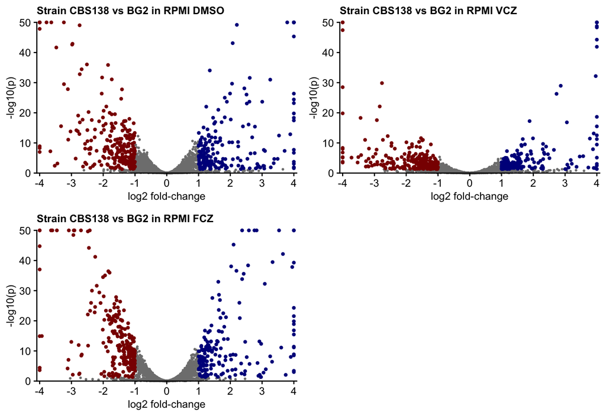

Report number of differentially expressed genes in CBS138 vs BG2:

```
## [1] "DMSO upregulated: 194, downregulated: 265"
```

```
## [1] "FCZ upregulated: 184, downregulated: 242"
```

```
## [1] "VCZ upregulated: 187, downregulated: 256"
```

### GO analysis of strain differences

DMSO upregulated in CBS138 (selected):

- amino acid biosynthesis
- cell adhesion
- spore wall assembly
- cell wall assembly

DMSO downregulated in CBS138 (selected):

- trehalose metabolism
- small molecule catabolism
- lipid catabolism

FCZ upregulated in CBS138:

- cell adhesion: AWP2, CAGL0A01584g, CAGL0I09856g, CAGL0K12078g, EPA23, EPA6

FCZ downregulated in CBS138 (selected):

- small molecule catabolism
- energy derivation by oxidation of organic compounds

VCZ upregulated in CBS138:

- cell adhesion: AWP2, CAGL0A01584g, CAGL0I09856g, EPA23, EPA3, EPA6
- filamentous growth: CAGL0H02145g, CAGL0I01254g, CAGL0I09856g, CAGL0K04169g, CAGL0M03663g, CAGL0M09042g, EFG1, SHO1, TEC1, YPS2

VCZ downregulated in CBS138:

- small molecule catabolism
- trehalose metabolism
- carbohydrate metabolism
- energy derivation by oxidation of organic compounds

## Analysis of Drug vs no Drug and strain differences

The above conclusions for pairwise comparisons suggest that we should compare:

- Drug vs no drug, taking average of VCZ and FCZ responses
- and compare across strains to get the strain-specific drug interactions

### Differential expression shared across both strains, both drugs

Here, “up” means that both drugs induces more transcript abundance in both strains. Essentially, treating both drugs as biological replicates, and both strains as biological replicates.

```r
sample_sheet_all_drugnodrug <-
  sample_sheet_all %>%
  # select only relevant columns
  dplyr::select(SampleID, Code, Strain, Medium, Rep) %>%
  # make Strain a factor in predictable order
  mutate(Strain = factor(Strain,
                         levels = c("BG2", "CBS138"))
         ) %>%
  # create two new columns for Drug, and Voriconazole vs Fluconazole
  mutate(Drug = Medium %in% c("RPMI_FLUC", "RPMI_VORI"),
         VORI = Medium %in% c("RPMI_VORI")) %>%
  magrittr::set_rownames(.$Code)
dds_drugnodrug_bc <-
  DESeqDataSetFromMatrix(
    countData = counts_all_joined %>%
      dplyr::select(sample_sheet_all_drugnodrug$Code) %>%
      magrittr::set_rownames(counts_all_joined$Gene),
    colData = sample_sheet_all_drugnodrug,
    design = ~ Strain + Drug) %>%
  DESeq()
resultsNames(dds_drugnodrug_bc)
```

```
## [1] "Intercept"            "Strain_CBS138_vs_BG2" "DrugTRUE"
```

```r
deseq_df_drugnodrug_bc  <-
  deseq_df_transform(dds_drugnodrug_bc,
                     termstokeep = "DrugTRUE")

deseq_df_drugnodrug_bc
```

```
## # A tibble: 5,124 × 5
##    gene         baseMean  log2FC stderror         padj
##    <chr>           <dbl>   <dbl>    <dbl>        <dbl>
##  1 CAGL0H10626g     220.  0.429    0.363  0.324
##  2 CAGL0A00165g     939.  0.333    0.0975 0.00167
##  3 CAGL0A00187g    2413.  0.358    0.136  0.0174
##  4 CAGL0A00209g    6755. -0.0959   0.115  0.501
##  5 CAGL0A00231g     515. -1.29     0.218  0.0000000196
##  6 CAGL0A00253g    2282.  0.0481   0.133  0.787
##  7 CAGL0A00275g    2973. -0.196    0.140  0.234
##  8 CAGL0A00297g    1698.  0.0577   0.115  0.699
##  9 CAGL0A00319g    1804.  0.418    0.0855 0.00000436
## 10 CAGL0A00341g     654.  0.883    0.205  0.0000584
## # ℹ 5,114 more rows
```

```r
DEGdf_up2x_FDR5_drug = get_upregulated_genes(deseq_df_drugnodrug_bc)
DEGdf_down2x_FDR5_drug = get_downregulated_genes(deseq_df_drugnodrug_bc)

print(DEGdf_up2x_FDR5_drug, n = 20)
```

```
## # A tibble: 258 × 5
##    gene         baseMean log2FC stderror      padj
##    <chr>           <dbl>  <dbl>    <dbl>     <dbl>
##  1 CAGL0A01089g   24754.   4.34    0.148 2.89e-185
##  2 CAGL0J03916g    8684.   3.88    0.169 1.56e-113
##  3 CAGL0L06094g    4710.   3.65    0.191 2.78e- 78
##  4 CAGL0F03641g    7427.   3.54    0.304 1.47e- 29
##  5 CAGL0K08668g    1429.   3.52    0.180 4.47e- 82
##  6 CAGL0D05940g   23664.   3.05    0.170 1.49e- 69
##  7 CAGL0M03839g   21921.   2.99    0.199 1.15e- 48
##  8 CAGL0B02838g    7089.   2.93    0.220 1.99e- 38
##  9 CAGL0F07029g    3902.   2.85    0.209 1.92e- 40
## 10 CAGL0B03663g    5540.   2.60    0.181 1.32e- 44
## 11 CAGL0M07403g    2557.   2.57    0.162 2.99e- 54
## 12 CAGL0M01760g   15392.   2.51    0.220 1.80e- 28
## 13 CAGL0D01474g    1672.   2.51    0.211 8.67e- 31
## 14 CAGL0C03872g   10721.   2.50    0.266 1.81e- 19
## 15 CAGL0K06677g     840.   2.45    0.195 2.91e- 34
## 16 CAGL0L06776g    1896.   2.44    0.206 1.96e- 30
## 17 CAGL0J04158g   13362.   2.43    0.202 1.85e- 31
## 18 CAGL0I05610g    6319.   2.40    0.205 9.53e- 30
## 19 CAGL0E05984g    2581.   2.38    0.479 3.07e-  6
## 20 CAGL0K10824g    1318.   2.36    0.193 3.33e- 32
## # ℹ 238 more rows
```

```r
print(DEGdf_down2x_FDR5_drug, n = 20)
```

```
## # A tibble: 355 × 5
##    gene         baseMean log2FC stderror     padj
##    <chr>           <dbl>  <dbl>    <dbl>    <dbl>
##  1 CAGL0H10076g    136.   -3.43    0.287 4.70e-31
##  2 CAGL0E02255g   1670.   -3.08    0.346 1.02e-17
##  3 CAGL0H08712g    114.   -2.84    0.285 6.21e-22
##  4 CAGL0L10142g    132.   -2.80    0.281 8.07e-22
##  5 CAGL0M03305g    627.   -2.78    0.500 1.45e- 7
##  6 CAGL0L01551g   1556.   -2.69    0.198 4.96e-40
##  7 CAGL0J05390g    208.   -2.46    0.384 1.07e- 9
##  8 CAGL0L13156g    229.   -2.25    0.261 1.10e-16
##  9 CAGL0B00792g    252.   -2.21    0.239 4.93e-19
## 10 CAGL0C02211g    674.   -2.21    0.217 9.15e-23
## 11 CAGL0K06259g   3403.   -2.19    0.306 8.23e-12
## 12 CAGL0K00605g    272.   -2.14    0.221 8.31e-21
## 13 CAGL0G03927g     99.4  -2.03    0.225 4.15e-18
## 14 CAGL0I09592g    938.   -1.93    0.288 1.89e-10
## 15 CAGL0F01463g 108605.   -1.90    0.281 1.19e-10
## 16 CAGL0D04620g    213.   -1.89    0.307 5.18e- 9
## 17 CAGL0F05709g    138.   -1.88    0.322 3.33e- 8
## 18 CAGL0L10890g   2359.   -1.87    0.212 2.38e-17
## 19 CAGL0C01749g   1326.   -1.85    0.162 1.86e-28
## 20 CAGL0G05742g   1416.   -1.83    0.141 1.14e-36
## # ℹ 335 more rows
```

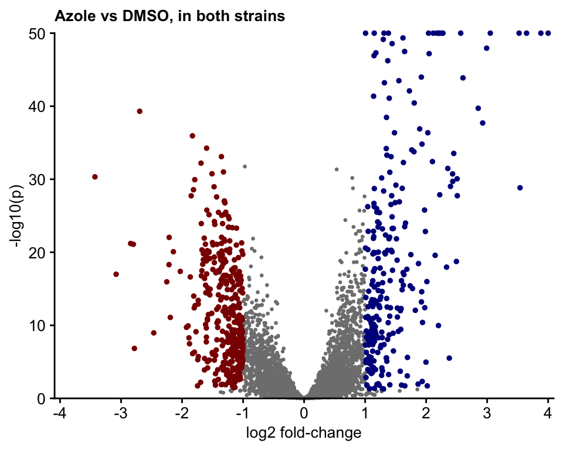

```r
volcano_plot(deseq_df_drugnodrug_bc, DEGdf_up2x_FDR5_drug, DEGdf_down2x_FDR5_drug) +
  ggtitle("Azole vs DMSO, in both strains")
```

```r
write.csv(deseq_df_drugnodrug_bc, "../data/deseq2/BothStrains_Drug_vs_DMSO_allDESeq.csv")
write.csv(DEGdf_up2x_FDR5_drug, "../data/deseq2/BothStrains_Drug_vs_DMSO_up2x_FDR5.csv")
writeLines(DEGdf_up2x_FDR5_drug$gene, "../data/deseq2/BothStrains_Drug_vs_DMSO_up2x_FDR5_names.txt")
write.csv(DEGdf_down2x_FDR5_drug, "../data/deseq2/BothStrains_Drug_vs_DMSO_down2x_FDR5.csv")
writeLines(DEGdf_down2x_FDR5_drug$gene, "../data/deseq2/BothStrains_Drug_vs_DMSO_down2x_FDR5_names.txt")
```

### Differential drug-strain interactions across strains

We’re looking for differential strain responses to drug. Here, “up” means that azoles induce more change in transcript abundance in CBS138 as compared to BG2. Again, treating both drugs as biological replicates, due to the small differences in response to the two diferent drugs.

```r
dds_drugstrain <-
  DESeqDataSetFromMatrix(
    countData = counts_all_joined %>%
      dplyr::select(sample_sheet_all_drugnodrug$Code) %>%
      magrittr::set_rownames(counts_all_joined$Gene),
    colData = sample_sheet_all_drugnodrug,
    design = ~ Strain * Drug) %>%
  DESeq()
resultsNames(dds_drugstrain)
```

```
## [1] "Intercept"             "Strain_CBS138_vs_BG2"  "DrugTRUE"
## [4] "StrainCBS138.DrugTRUE"
```

```r
deseq_df_drugstrain  <-
  deseq_df_transform(dds_drugstrain,
                     termstokeep = "StrainCBS138.DrugTRUE")

deseq_df_drugstrain
```

```
## # A tibble: 5,124 × 5
##    gene         baseMean  log2FC stderror  padj
##    <chr>           <dbl>   <dbl>    <dbl> <dbl>
##  1 CAGL0H10626g     220. -0.916     1.18  0.986
##  2 CAGL0A00165g     939.  0.220     0.192 0.986
##  3 CAGL0A00187g    2413.  0.0531    0.279 0.991
##  4 CAGL0A00209g    6755.  0.0379    0.237 0.991
##  5 CAGL0A00231g     515.  0.865     0.399 0.546
##  6 CAGL0A00253g    2282.  0.0776    0.273 0.991
##  7 CAGL0A00275g    2973.  0.0260    0.288 0.993
##  8 CAGL0A00297g    1698.  0.321     0.222 0.899
##  9 CAGL0A00319g    1804.  0.322     0.152 0.583
## 10 CAGL0A00341g     654.  0.272     0.417 0.986
## # ℹ 5,114 more rows
```

```r
DEGdf_up2x_FDR5_drugstrain = get_upregulated_genes(deseq_df_drugstrain)
DEGdf_down2x_FDR5_drugstrain = get_downregulated_genes(deseq_df_drugstrain)

print(DEGdf_up2x_FDR5_drugstrain, n = 20)
```

```
## # A tibble: 9 × 5
##   gene         baseMean log2FC stderror      padj
##   <chr>           <dbl>  <dbl>    <dbl>     <dbl>
## 1 CAGL0J02530g     466.   2.07    0.376 0.0000599
## 2 CAGL0L06776g    1896.   1.37    0.274 0.000471
## 3 CAGL0I09856g    1624.   1.35    0.368 0.0246
## 4 CAGL0K04719g    2367.   1.29    0.348 0.0238
## 5 CAGL0M06347g    2086.   1.24    0.235 0.000134
## 6 CAGL0L08426g    1163.   1.23    0.331 0.0233
## 7 CAGL0K10824g    1318.   1.18    0.289 0.00899
## 8 CAGL0M08800g    1528.   1.18    0.327 0.0290
## 9 CAGL0M03839g   21921.   1.12    0.313 0.0325
```

```r
print(DEGdf_down2x_FDR5_drugstrain, n = 20)
```

```
## # A tibble: 22 × 5
##    gene         baseMean log2FC stderror          padj
##    <chr>           <dbl>  <dbl>    <dbl>         <dbl>
##  1 CAGL0F06875g  11158.   -2.81    0.398 0.00000000921
##  2 CAGL0J06402g   2664.   -2.34    0.472 0.000508
##  3 CAGL0M01892g     39.9  -1.90    0.510 0.0233
##  4 CAGL0G02585g   8260.   -1.79    0.385 0.00170
##  5 CAGL0F02431g   5599.   -1.77    0.394 0.00288
##  6 CAGL0F04917g    114.   -1.73    0.441 0.0151
##  7 CAGL0I09592g    938.   -1.72    0.450 0.0203
##  8 CAGL0K07788g  14241.   -1.67    0.431 0.0167
##  9 CAGL0C03872g  10721.   -1.67    0.399 0.00763
## 10 CAGL0I08987g    949.   -1.47    0.402 0.0253
## 11 CAGL0L02079g   7782.   -1.47    0.322 0.00224
## 12 CAGL0K11616g   5367.   -1.44    0.340 0.00697
## 13 CAGL0J09240g   9171.   -1.44    0.354 0.0100
## 14 CAGL0E06688g    683.   -1.37    0.341 0.0107
## 15 CAGL0C03443g  15756.   -1.34    0.297 0.00275
## 16 CAGL0B01507g    734.   -1.27    0.233 0.0000599
## 17 CAGL0G04807g   1090.   -1.21    0.321 0.0222
## 18 CAGL0L01551g   1556.   -1.18    0.287 0.00899
## 19 CAGL0I07711g    387.   -1.16    0.285 0.0100
## 20 CAGL0G08668g   2336.   -1.14    0.263 0.00538
## # ℹ 2 more rows
```

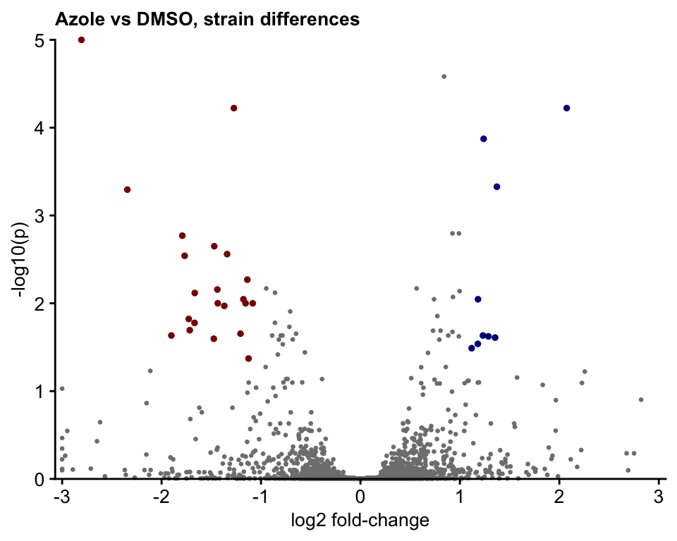

```r
volcano_plot(deseq_df_drugstrain, DEGdf_up2x_FDR5_drugstrain, DEGdf_down2x_FDR5_drugstrain,
             ylimits = c(0,5),
             xlimits = c(-3,3)) +
  ggtitle("Azole vs DMSO, strain differences")
```

```r
write.csv(deseq_df_drugstrain, "../data/deseq2/DrugStrain_CBS138_vs_BG2_allDESeq.csv")
write.csv(DEGdf_up2x_FDR5_drugstrain, "../data/deseq2/DrugStrain_CBS138_vs_BG2_up2x_FDR5.csv")
writeLines(DEGdf_up2x_FDR5_drugstrain$gene, "../data/deseq2/DrugStrain_CBS138_vs_BG2_up2x_FDR5_names.txt")
write.csv(DEGdf_down2x_FDR5_drugstrain, "../data/deseq2/DrugStrain_CBS138_vs_BG2_down2x_FDR5.csv")
writeLines(DEGdf_down2x_FDR5_drugstrain$gene, "../data/deseq2/DrugStrain_CBS138_vs_BG2_down2x_FDR5_names.txt")
```

## Venn Diagram of DEG lists

```r
library(VennDiagram)
```

```r
# Generate 3 sets of 200 words
set1 <- paste(rep("word_" , 200) , sample(c(1:1000) , 200 , replace=F) , sep="")
set2 <- paste(rep("word_" , 200) , sample(c(1:1000) , 200 , replace=F) , sep="")
set3 <- paste(rep("word_" , 200) , sample(c(1:1000) , 200 , replace=F) , sep="")

set.seed(20190708)
genes <- paste("gene",1:1000,sep="")
x <- list(
  A = sample(genes,300),
  B = sample(genes,525),
  C = sample(genes,440),
  D = sample(genes,350)
  )

# Chart
venn.diagram(
  x = list(set1, set2, set3),
  category.names = c("Set 1" , "Set 2 " , "Set 3"),
  filename = NULL,
  output=TRUE
)
```

[output not shown]

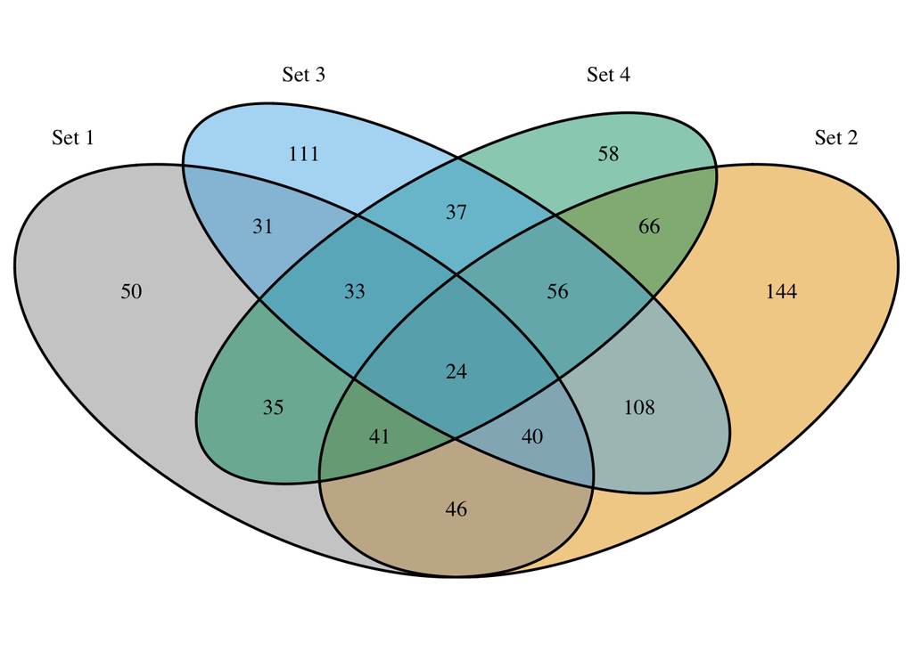

```r
display_venn <- function(x, ...){
  library(VennDiagram)
  grid.newpage()
  venn_object <- venn.diagram(x, filename = NULL, ...)
  grid.draw(venn_object)
}
display_venn(
  x,
  category.names = c("Set 1" , "Set 2 " , "Set 3", "Set 4"),
  fill = c("#999999", "#E69F00", "#56B4E9", "#009E73")
  )
```

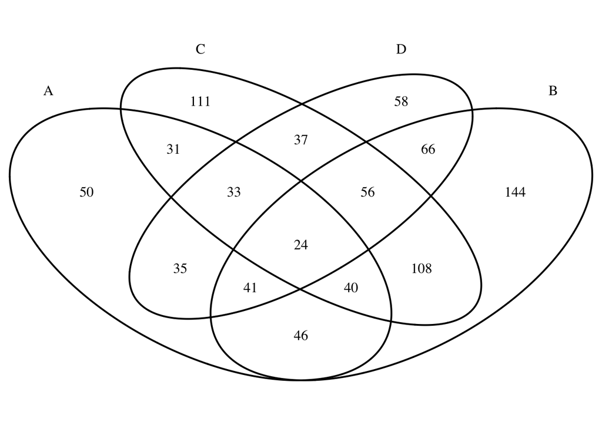

```r
display_venn(x)
```

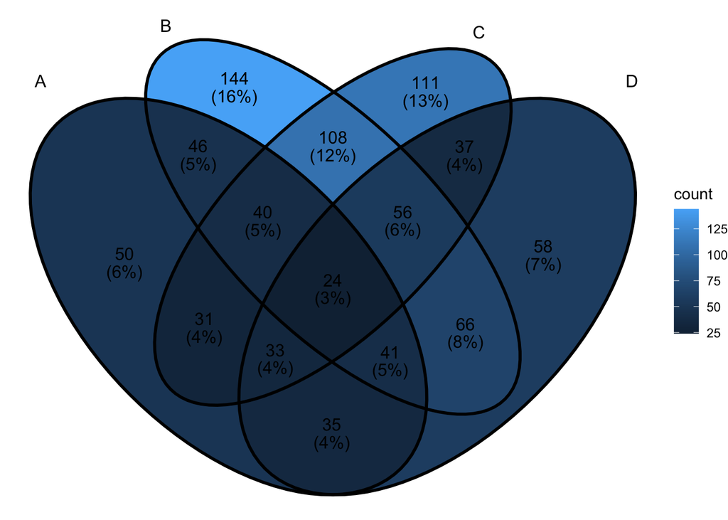

```r
library("ggVennDiagram")
ggVennDiagram(x, label_alpha = 0)
```

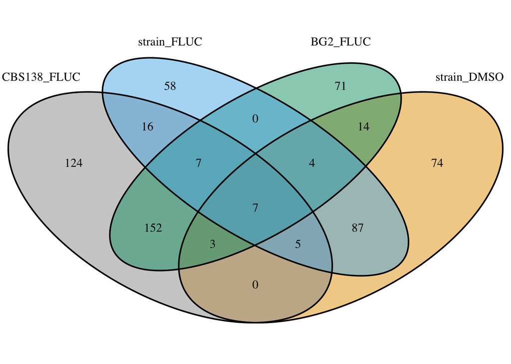

```r
cf_up = as.vector(ortho_cb_c_up$gene)
cbd_up = as.vector(DEGdf_up2x_FDR5_cbd$gene)
cbf_up = as.vector(DEGdf_up2x_FDR5_cbf$gene)
bf_up = as.vector(ortho_cb_b_up$gene_id_cbs138)

y <- list(
  CBS138_FLUC = cf_up,
  strain_DMSO = cbd_up,
  strain_FLUC = cbf_up,
  BG2_FLUC = bf_up
  )

display_venn(
  y,
  fill = c("#999999", "#E69F00", "#56B4E9", "#009E73")
  )
```

```r
print(head(DEGdf_up2x_FDR5_cbd))
```

```
## # A tibble: 6 × 5
##   gene         baseMean log2FC stderror      padj
##   <chr>           <dbl>  <dbl>    <dbl>     <dbl>
## 1 CAGL0K00110g   13966.  12.5     0.809 3.70e- 51
## 2 CAGL0C00110g    4327.  10.3     0.274 1.58e-303
## 3 CAGL0H10626g     203.   9.79    0.873 4.30e- 27
## 4 CAGL0E00187g     550.   8.81    0.816 3.86e- 25
## 5 CAGL0E06666g    2836.   8.68    0.823 6.27e- 24
## 6 CAGL0K13024g    1275.   8.65    0.334 9.32e-145
```

```python
import pandas as pd

plt.rcParams['svg.fonttype'] = 'none'

rlog_all_p = r.rlog_all_df
rlog_all_p = rlog_all_p.reset_index().rename(columns={'index': 'Geneid'})


filamentous_genes = ["CAGL0H02145g",    "CAGL0I01254g", "CAGL0I09856g", "CAGL0K04169g", "CAGL0M03663g", "CAGL0M09042g"]
cell_adhesion_genes = ["CAGL0K00110g", "CAGL0A01584g", "CAGL0I09856g", "CAGL0K12078g", "CAGL0I00220g", "CAGL0E06688g", "CAGL0C00110g"]

s = rlog_all_p[rlog_all_p["Geneid"].isin(cell_adhesion_genes)]

t = s.set_index("Geneid")
#plt.figure(figsize=(10, 10))
#plt.subplots_adjust(left=0.5, right=1.5, bottom=4.0)
g = sns.clustermap(t, cmap='vlag', method="single", annot_kws={"size": 7})
plt.setp(g.ax_heatmap.get_yticklabels(), rotation=0)  # For y axis
plt.show()
#plt.savefig("/Users/s1964600/Work/random_figures/new_svg/cpac_scer_deg.svg")
plt.close()
```

[output not shown]

TODOs:

- look at the orthogroups for differences between the species
- change data formatting to have one file with orthology information instead of multiple files for every condition
- extend the analysis of regulation, including the strain differences
- less text, more figures